DS 6030 | Fall 2023 | University of Virginia

# Homework #1: Supervised Learning

Author

Published

September 5, 2023

# Required R packages and Directories

```r
data.dir = 'https://mdporter.github.io/SYS6030/data/' # data directory
library(tidyverse) # functions for data manipulation
library(ggplot2)
```

# Problem 1: Evaluating a Regression Model

## a. Data generating functions

Create a set of functions to generate data from the following distributions:

$$\begin{align*}
X &\sim \mathcal{N}(0, 1) \\
Y &= -1 + .5X + .2X^2 + \epsilon \\
\epsilon &\sim \mathcal{N}(0,\, \sigma)
\end{align*}$$

**Solution**

```r
## normal dist
x_vals = function(n){
  rnorm(n)
}
## function equation
func = function(x){
  -1+(0.5*x)+(0.2*x^2)
}
## y dist
y_vals = function(x, sd=1){
  n = length(x)
  func(x)+rnorm(n, sd=sd)
}
```

## b. Generate training data

Simulate $n=100$ realizations from these distributions using $\sigma=3$. Produce a scatterplot and draw the true regression line $f(x) = E[Y \mid X=x]$. - Use `set.seed(611)` prior to generating the data.

**Solution**

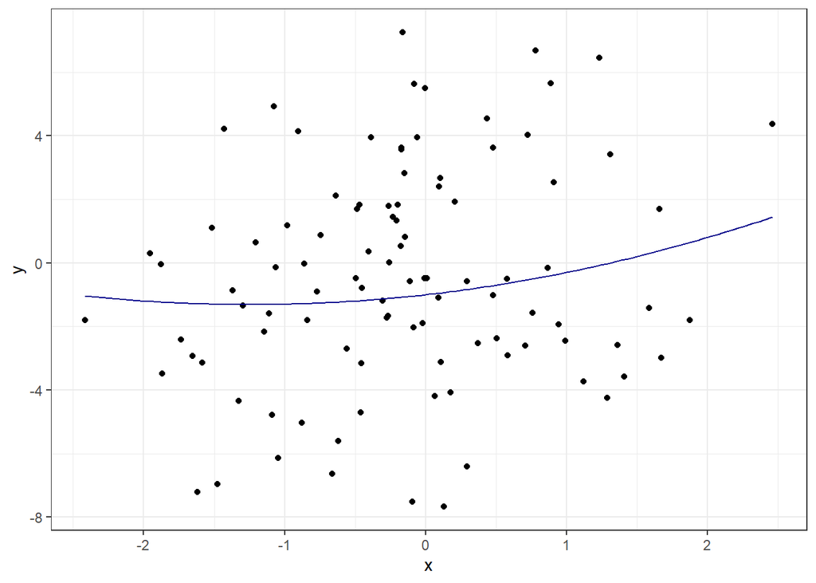

```r
set.seed(611)
n=100
sd=3
x = x_vals(n)
y = y_vals(x, sd)
tib = tibble(x=x, y=y)
ggplot(data=tib)+
  geom_point(aes(x=x, y=y))+
  geom_function(fun = func, color="darkblue")+
  theme_bw()
```

## c. Fit three models

Fit three polynomial regression models using least squares: linear, quadratic, and cubic. Produce another scatterplot, add the fitted lines and true population line $f(x)$ using different colors, and add a legend that maps the line color to a model.

- Note: The true model is quadratic, but we are also fitting linear (less complex) and cubic (more complex) models.

**Solution**

```r
dg = tibble(x=seq(-3,3,length=100))
```

```r
lin = lm(y~x, data=tib)
l = predict(lin, dg)
cub = lm(y~poly(x, degree=3), data=tib)
c = predict(cub, dg)
```

```r
preds = dg %>%
  mutate(linear=l, cubic=c) %>%
  pivot_longer(cols=c(linear, cubic), names_to = "model", values_to = ".pred")
```

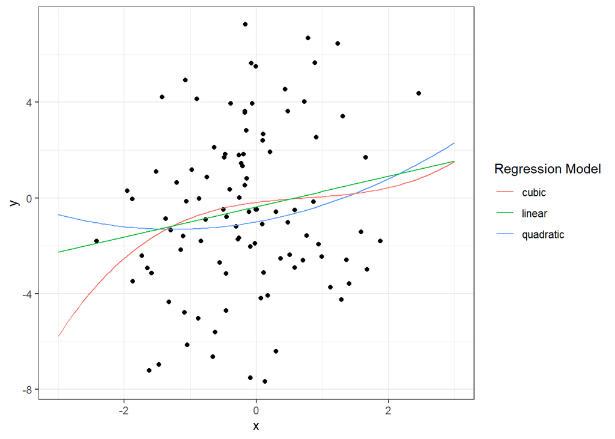

```r
ggplot(tib)+
  geom_point(aes(x=x, y=y))+
  geom_function(fun=func, aes(color="quadratic"))+
  geom_line(data=preds, aes(x=x, y=.pred, color=model))+
  labs(color="Regression Model")
```

## d. Predictive performance

Generate a *test data* set of 10,000 observations from the same distributions. Use `set.seed(612)` prior to generating the test data.

- Calculate the estimated mean squared error (MSE) for each model.
- Are the results as expected?

**Solution**

```r
set.seed(612)
n=10000
sd=3
x = x_vals(n)
y = y_vals(x, sd)
test = tibble(x=x, y=y)
```

```r
poly_eval <- function(deg, data_train, data_test){
  if(deg==0) m = lm(y~1, data=data_train) # intercept only model
  else m = lm(y~poly(x, degree=deg), data=data_train) # polynomial
  p = length(coef(m)) # number of parameters
  mse.train = mean(m$residuals^2) # training MSE
  yhat = predict(m, data_test) # predictions at test X's
  mse.test = mean( (data_test$y - yhat)^2 )# test MSE
  tibble(degree=deg, edf=p, mse.train, mse.test)
}
```

```r
deg_seq = c(1,2,3)
perf_poly = map_df(deg_seq, ~poly_eval(., data_train=tib, data_test=test))
```

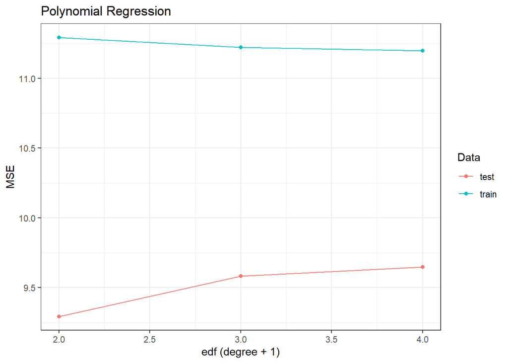

```r
perf_poly %>%
  pivot_longer(starts_with("mse"), names_to="data", values_to="mse") %>%
  mutate(data = str_remove(data, "mse\\.")) %>%
  ggplot(aes(edf, mse, color=data))+
  geom_line()+
  geom_point()+
  labs(title="Polynomial Regression",
       x = 'edf (degree + 1)',
       y="MSE",
       color="Data")+
  theme_bw()
```

```r
perf_poly
```

```
# A tibble: 3 × 4
  degree   edf mse.train mse.test
   <dbl> <int>     <dbl>    <dbl>
1      1     2      11.3     9.29
2      2     3      11.2     9.58
3      3     4      11.2     9.65
```

The results were surprising because according to the MSE for the test data, the model with the lowest MSE is the linear model, not the ‘true’ model (quadratic model).

## e. Optimal performance

What is the best achievable MSE? That is, what is the MSE if the true $f(x)$ was used to evaluate the test set? How close does the best method come to achieving the optimum?

**Solution**

The standard deviation is 3, so the variance is 9. Therefore, the optimum MSE is 9 as well. With the true function (quadratic function with edf of 3), the MSE for the test data is around 9.58, which is considerably close to the optimum MSE.

## f. Replication

The MSE scores obtained in part *d* came from one realization of training data. Here will we explore how much variation there is in the MSE scores by replicating the simulation many times.

- Re-run parts b. and c. (i.e., generate training data and fit models) 100 times.
  - Do not generate new testing data
  - Use `set.seed(613)` prior to running the simulation and do not set the seed in any other places.
- Calculate the test MSE for all simulations.
  - Use the same test data from part d. (This question is only about the variability that comes from the *training data*).
- Create kernel density or histogram plots of the resulting MSE values for each model.

**Solution**

```r
## part b
set.seed(613)
rep_train = function(reps){
  train = list()
  for (i in 1:reps){
    n=100
    sd=3
    x = x_vals(n)
    y = y_vals(x, sd)
    train = append(train, list(tibble(x=x, y=y)))
  }
  train
}
```

```r
rep.train = rep_train(100)
```

```r
## part c
rep_lin = function(mylist){
  all_preds = list()
  for (i in mylist){
    dg = tibble(x=seq(-3,3,length=100))
    lin = lm(i$y~i$x, data=i)
    l = predict(lin, dg)
    cub = lm(y~poly(x, degree=3), data=i)
    c = predict(cub, dg)
    preds = dg %>%
      mutate(linear=l, cubic=c) %>%
      pivot_longer(cols=c(linear, cubic), names_to = "model", values_to = ".pred")
    all_preds = append(all_preds, list(preds))
  }
  all_preds
}
```

```r
rep.lin = rep_lin(rep.train)
```

```r
poly100 = function(training){
  deg_seq = c(1,2,3)
  poly_list = list()
  for (i in training){
    perf_poly = map_df(deg_seq, ~poly_eval(., data_train=i, data_test=test)) %>%
      pivot_longer(starts_with("mse"), names_to="data", values_to="mse") %>%
      mutate(data = str_remove(data, "mse\\."))
    poly_list = append(poly_list, list(perf_poly))
  }
  poly_list
}
```

```r
polydf = poly100(rep.train)
```

```r
new_polydf = bind_rows(polydf, .id="n rep") %>%
  filter(data=='train')
```

```r
new_polydf$degree = as.factor(new_polydf$degree)
```

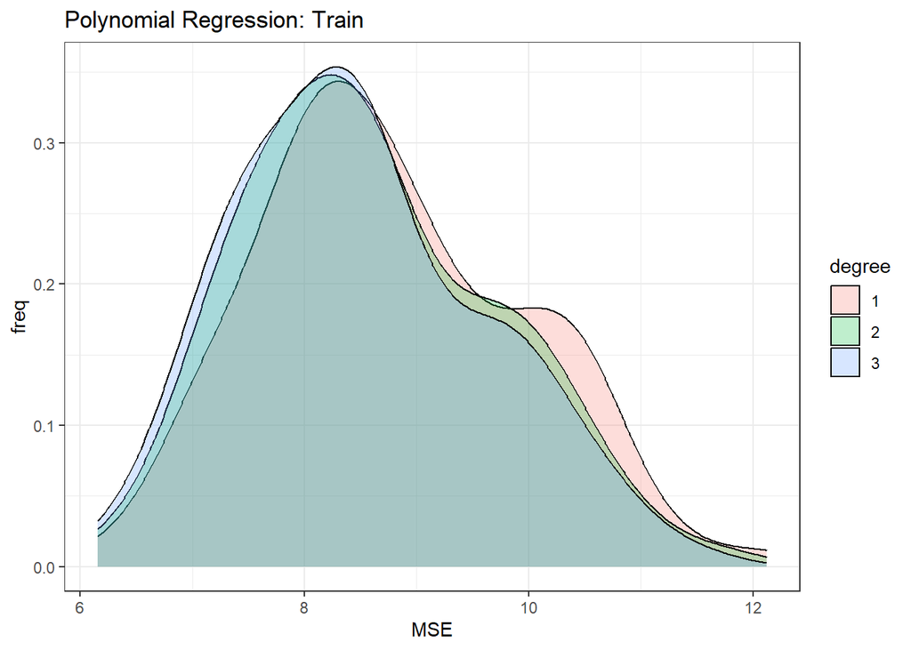

```r
ggplot(data=new_polydf)+
  geom_density(aes(x=mse, fill=degree),
               alpha=0.25)+
  #facet_wrap(~degree, ncol=1)+
  labs(title="Polynomial Regression: Train",
       x = 'MSE',
       y="freq",
       fill="degree")+
  theme_bw()
```

```r
new_polydf2 = bind_rows(polydf, .id="n_rep") %>%
  filter(data=='test')
```

```r
new_polydf2$degree = as.factor(new_polydf$degree)
```

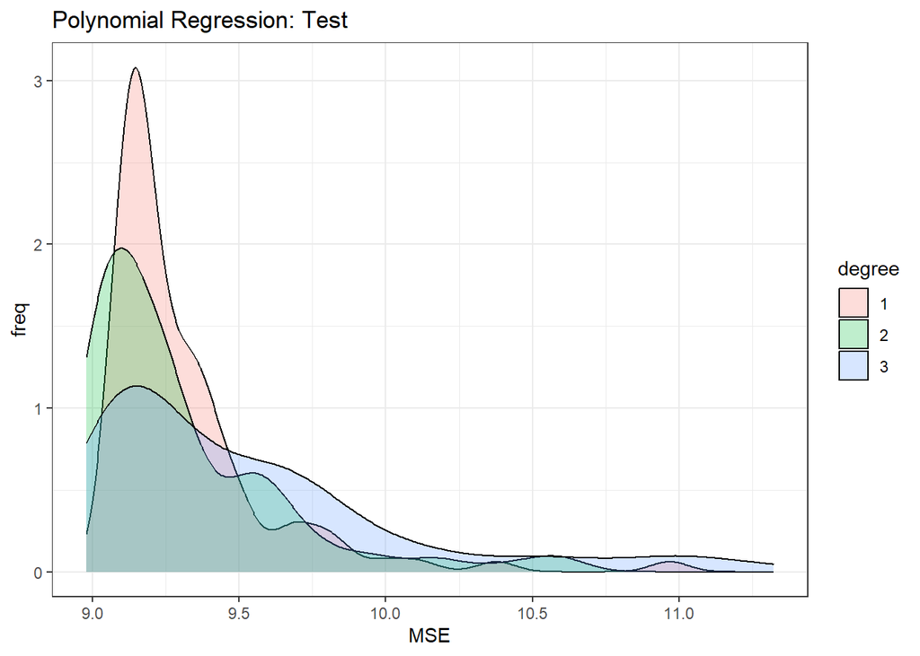

```r
ggplot(data=new_polydf2)+
  geom_density(aes(x=mse, fill=degree),
               alpha=0.25)+
  #facet_wrap(~degree, ncol=1)+
  labs(title="Polynomial Regression: Test",
       x = 'MSE',
       y="freq",
       fill="degree")+
  theme_bw()
```

## g. Best model

Show a count of how many times each model was the best. That is, out of the 100 simulations, count how many times each model had the lowest MSE.

**Solution**

```r
lowestMSE = new_polydf2 %>%
  group_by(n_rep) %>%
  filter(mse==min(mse)) %>%
  group_by(degree) %>%
  summarise("count"=n())
lowestMSE
```

```
# A tibble: 3 × 2
  degree count
  <fct>  <int>
1 1         28
2 2         65
3 3          7
```

## h. Function to implement simulation

Write a function that implements the simulation in part *f*. The function should have arguments for i) the size of the training data $n$, ii) the standard deviation of the random error $\sigma$, and iii) the test data. Use the same `set.seed(613)`.

**Solution**

```r
train_sim = function(n, sigma, test_data, reps=100){
  train = list()
  for (i in 1:reps){
    n=n
    sd=sigma
    x = x_vals(n)
    y = y_vals(x, sd)
    train = append(train, list(tibble(x=x, y=y)))
  }

  deg_seq = c(1,2,3)
  poly_list = list()
  for (i in train){
    perf_poly = map_df(deg_seq, ~poly_eval(., data_train=i, data_test=test)) %>%
      pivot_longer(starts_with("mse"), names_to="data", values_to="mse") %>%
      mutate(data = str_remove(data, "mse\\."))
    poly_list = append(poly_list, list(perf_poly))
  }

  polydf = bind_rows(poly_list, .id="n_rep") %>%
  filter(data=='test')
  polydf$degree = as.factor(polydf$degree)
  polydf
}
```

## i. Performance when $\sigma=2$

Use your function to repeat the simulation in part *f*, but use $\sigma=2$. Report the number of times each model was best (you do not need to produce any plots).

- First generate new test data with ($n = 10000$, $\sigma = 2$, using `seed = 612`).

**Solution**

```r
set.seed(612)
x = x_vals(10000)
y = y_vals(x, 2)
test = tibble(x=x, y=y)
```

```r
n=100
sd=2
newsim = train_sim(n=n, sigma=sd, test_dat=test)
newsim
```

```
# A tibble: 300 × 5
  n_rep degree   edf data    mse
  <chr> <fct>  <int> <chr> <dbl>
1 1     1          2 test   4.21
2 1     2          3 test   4.14
3 1     3          4 test   4.52
4 2     1          2 test   4.29
5 2     2          3 test   4.18
6 2     3          4 test   4.17
# ℹ 294 more rows
```

```r
lowestMSE = newsim %>%
  group_by(n_rep) %>%
  filter(mse==min(mse)) %>%
  group_by(degree) %>%
  summarise("count"=n())
lowestMSE
```

```
# A tibble: 3 × 2
  degree count
  <fct>  <int>
1 1         16
2 2         66
3 3         18
```

## j. Performance when $\sigma=4$ and $n=300$

Repeat *i*, but now use $\sigma=4$ and $n=300$.

- First generate new test data with ($n = 10000$, $\sigma = 4$, using `seed = 612`).

**Solution**

```r
set.seed(612)
x = x_vals(10000)
y = y_vals(x, 4)
test = tibble(x=x, y=y)
```

```r
n = 300
sd = 4
newsim = train_sim(n=n, sigma=sd, test_dat=test)
newsim
```

```
# A tibble: 300 × 5
  n_rep degree   edf data    mse
  <chr> <fct>  <int> <chr> <dbl>
1 1     1          2 test   16.1
2 1     2          3 test   16.0
3 1     3          4 test   16.0
4 2     1          2 test   16.2
5 2     2          3 test   16.0
6 2     3          4 test   16.1
# ℹ 294 more rows
```

```r
lowestMSE = newsim %>%
  group_by(n_rep) %>%
  filter(mse==min(mse)) %>%
  group_by(degree) %>%
  summarise("count"=n())
lowestMSE
```

```
# A tibble: 3 × 2
  degree count
  <fct>  <int>
1 1         12
2 2         68
3 3         20
```

## k. Understanding

Describe the effects $\sigma$ and $n$ has on selection of the best model? Why is the *true* model form (i.e., quadratic) not always the *best* model to use when prediction is the goal?

**Solution**

I personally don’t see that much of a difference between the models when changing the size or standard deviation. I noticed that regardless of the size or the standard deviation, the true model has more instances of having the lowest MSE compared to the two other models.

If the true model is used for prediction, there’s a possibility that the model would overfit the data when applied to larger testing models. Therefore, the prediction power of the model would decrease due to the model fitting too well to the training data.